# Praca domowa 1

## 2. Boxplot

Na wykresie przedstawimy masy roślinek w zależności od badanej grupy.

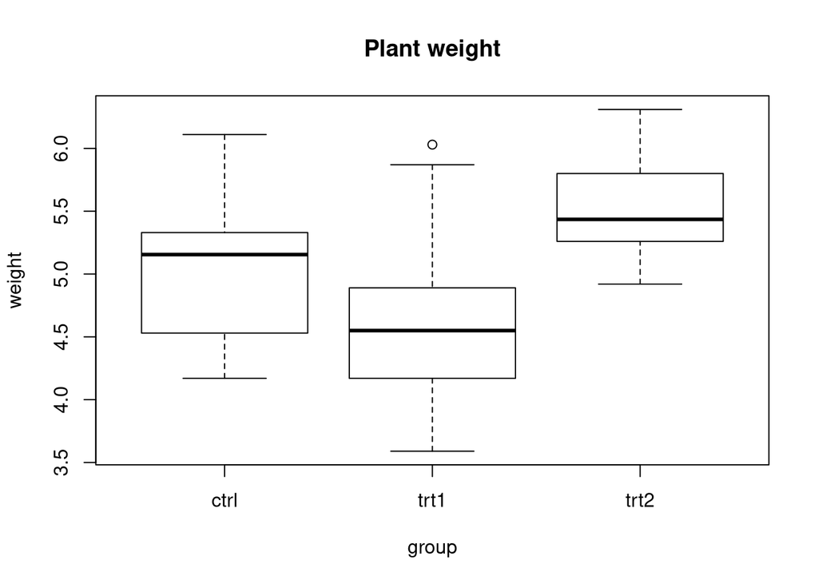

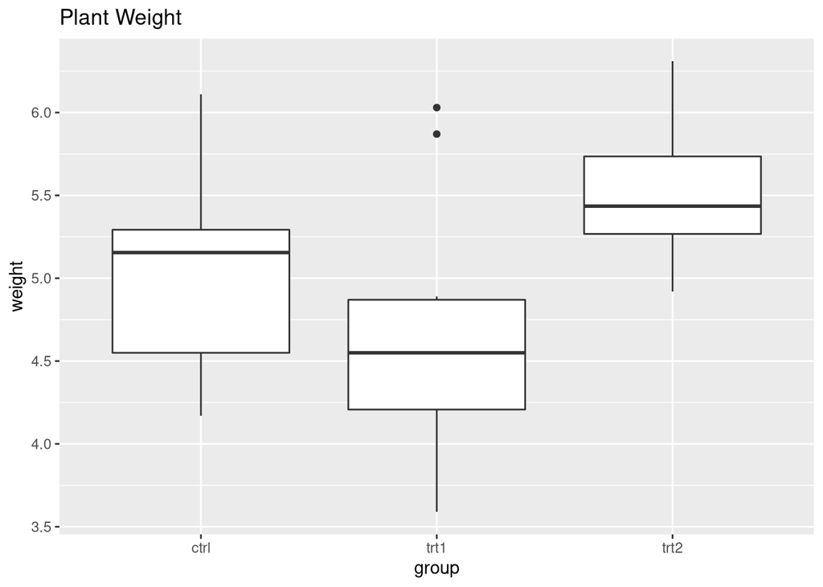

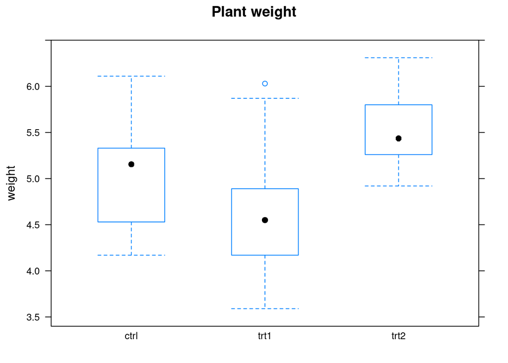

```r
quote(
  boxplot(weight ~ group, PlantGrowth, main = "Plant weight")
) -> gr2
quote(ggplot(PlantGrowth, aes(x = group, y = weight)) +
  geom_boxplot() +
  labs(title="Plant Weight")) -> gg2
quote(
  bwplot(weight ~ group, PlantGrowth, main="Plant weight")
) -> la2
eval(gr2)
eval(gg2)
eval(la2)
```

## 3. Scatterplot

Na wykresie przedstawimy zależność ilości osób poszkodowanych w wypadkach samochodowych w Wielkiej Brytanii w danym roku od ceny paliwa w danym roku. Interesować nas będą tylko przypadki przed wprowadzeniem nakazu zapinania pasów (*law == 0*). Ponadto dorysujemy prostą najlepszego dopasowania.

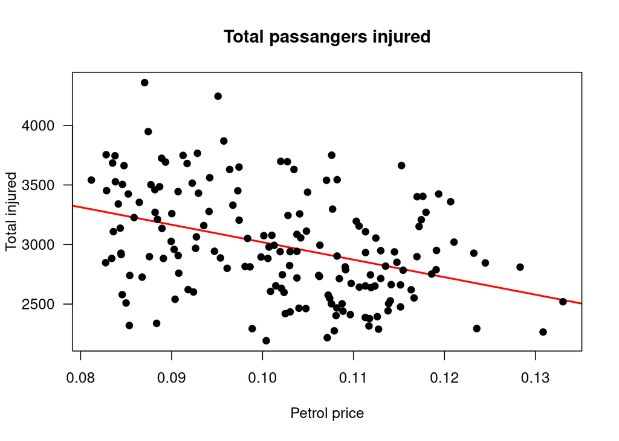

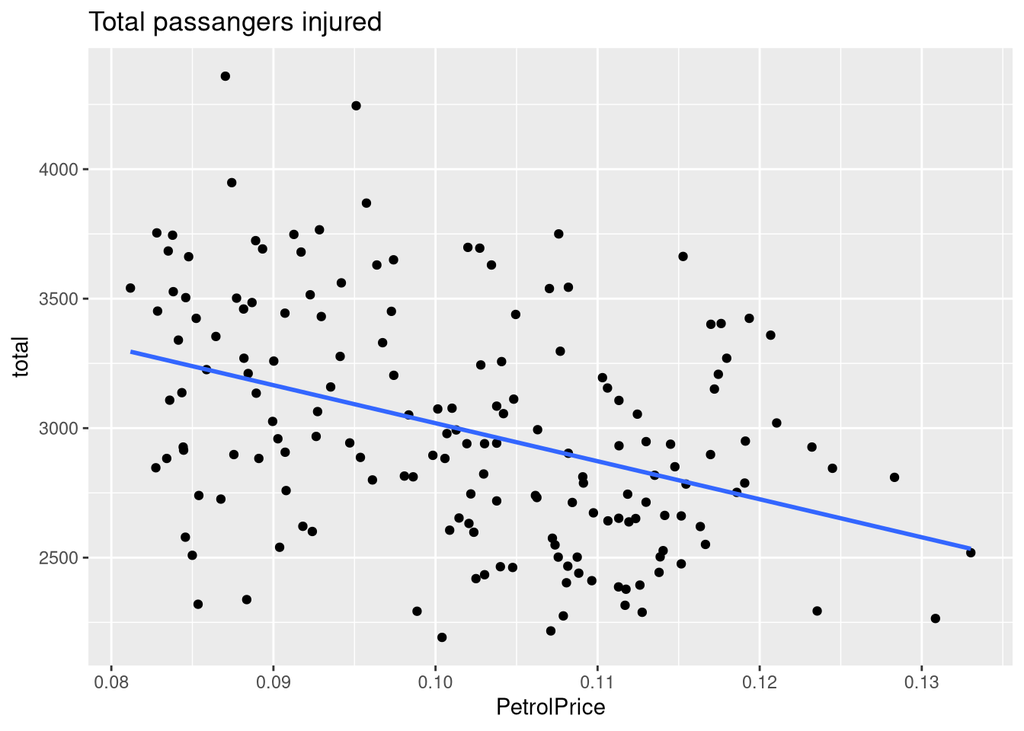

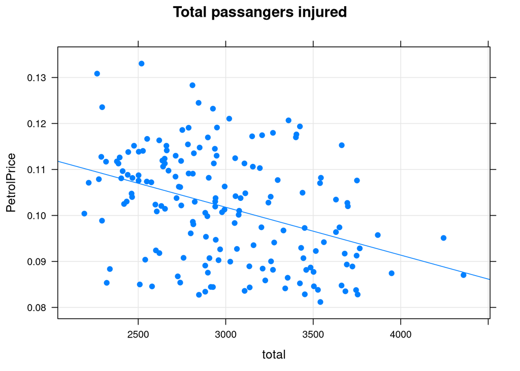

```r
Seatbelts%>%as.data.frame()%>%
mutate(total=drivers+front+rear)%>%
  filter(law==0)%>%
  select(total, PetrolPrice)->Seatbelts2

quote(
  plot(Seatbelts2$PetrolPrice, Seatbelts2$total, pch=19,
     las=1, xlab="Petrol price", ylab="Total injured",
     abline(lm(Seatbelts2$total~Seatbelts2$PetrolPrice), col=2, lwd = 2),
     main="Total passangers injured")
) -> gr3
quote(
  ggplot(Seatbelts2, aes(x = PetrolPrice, y = total)) +
  geom_point() +
  geom_smooth(method = "lm", se=F) +
  labs(title = "Total passangers injured")
) -> gg3
quote(
  xyplot(PetrolPrice ~ total, Seatbelts2,
       type=c("p","r", "g"), pch = 19, main = "Total passangers injured")
) -> la3
eval(gr3)
eval(gg3)
eval(la3)
```

## 4. Timeseries

Na wykresie przedstawimy temperaturę w Nowym Jorku w 2013 r. w zależności od dnia.

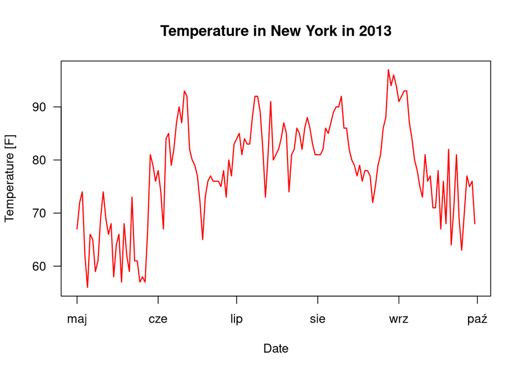

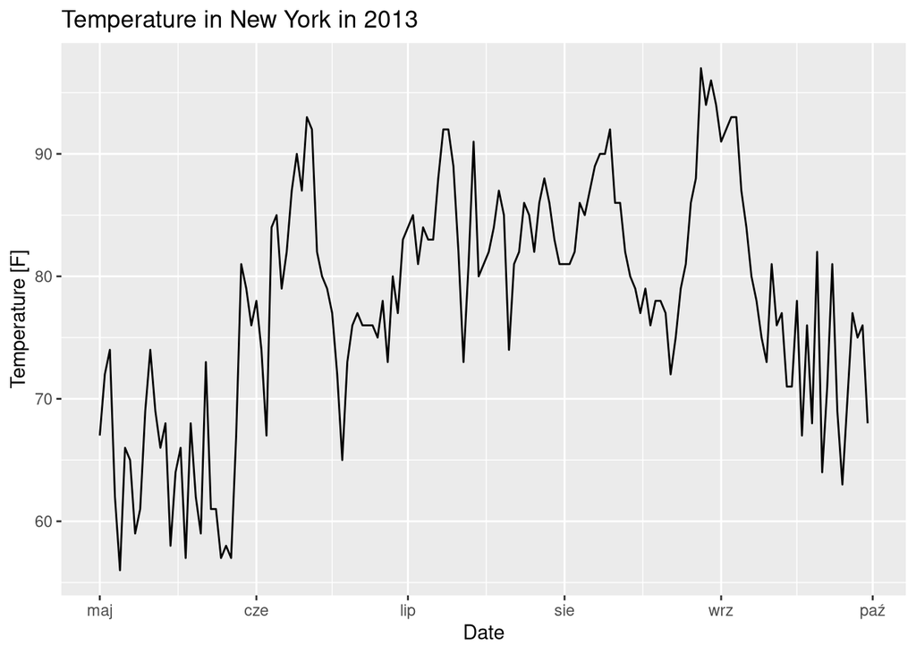

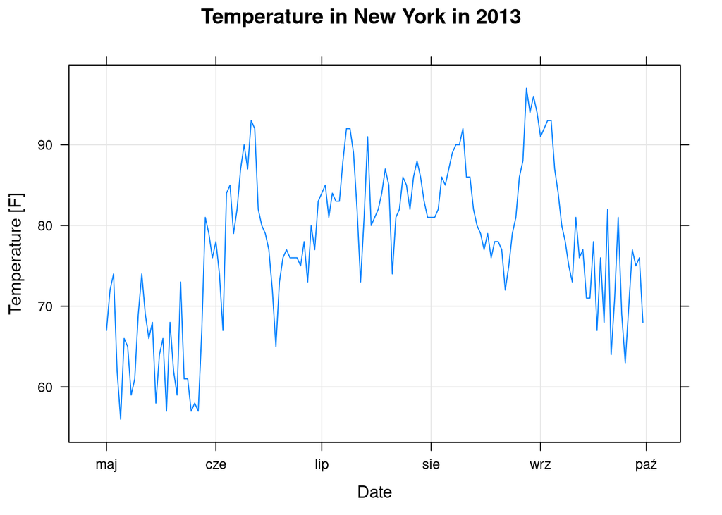

```r
mutate(airquality, Date = paste("2013",
                                 format(Month, width = 2),
                                 format(Day, width = 2),
                                sep="-") %>% as.Date()) %>%
  select(Date, Temp)->Airquality
quote(
  plot(Airquality$Date, airquality$Temp, type = 'l', col='red',
     xlab="Date",
     ylab="Temperature [F]",
     main="Temperature in New York in 2013",
     las=1, lwd = 1.5)
) -> gr4
quote(
  ggplot(Airquality, aes(Date, Temp)) +
  geom_line() +
  labs(title = "Temperature in New York in 2013") +
  ylab("Temperature [F]")
) -> gg4
quote(
  xyplot(Temp ~ Date, Airquality, type = c("l","g"),
       main = "Temperature in New York in 2013",
       ylab = "Temperature [F]")
) -> la4
eval(gr4)
eval(gg4)
eval(la4)
```

## 5. Diverging barplot

Na wykresie przedstawimy ustandaryzowaną powierzchnię stanów USA.

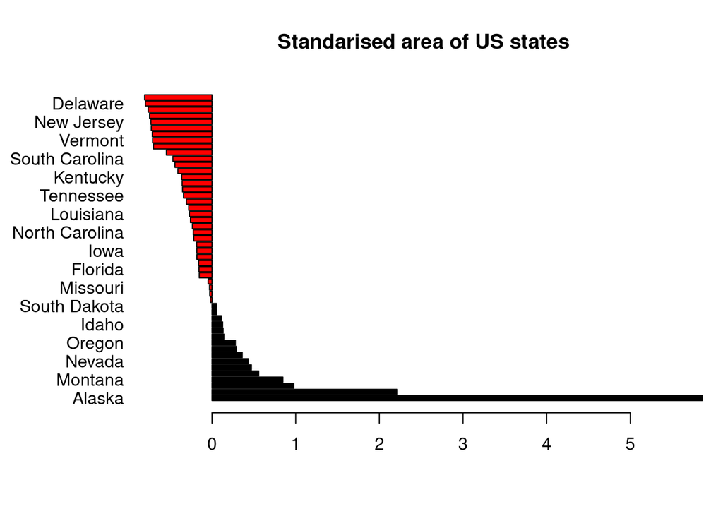

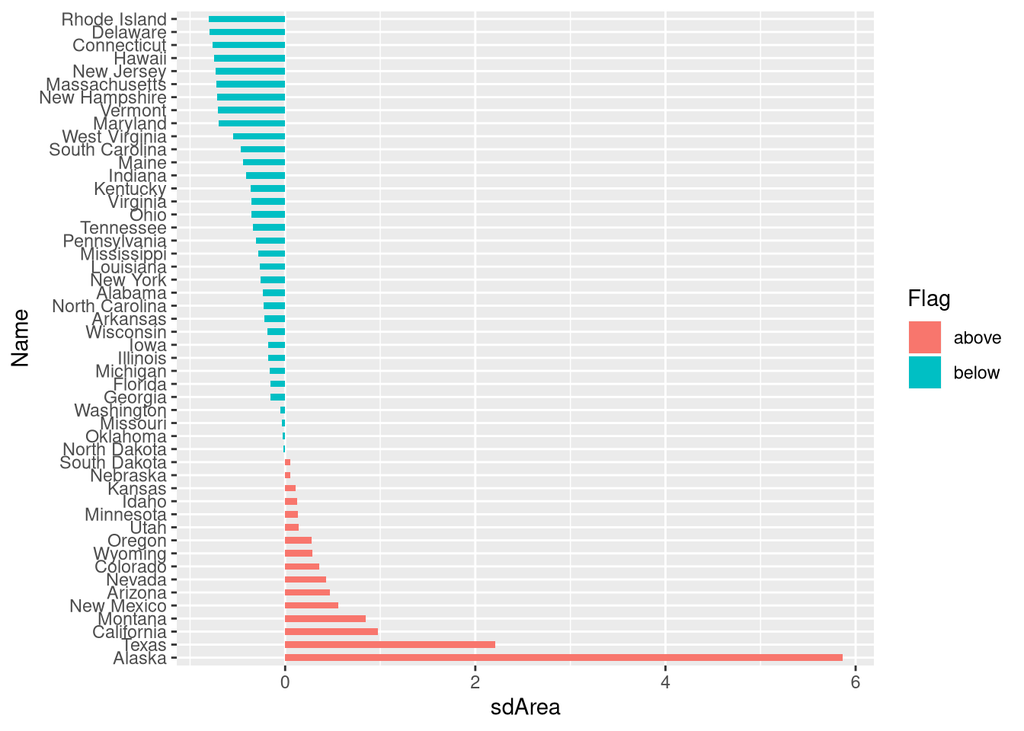

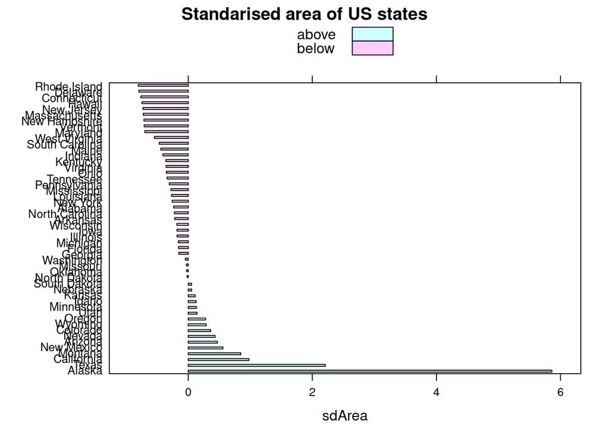

```r
par("mar"=c(5,7,4,1))
data.frame(Name=state.name, Area=state.area)%>%
  mutate(sdArea=(Area-mean(Area))/sd(Area),
         Flag = if_else(sdArea>=0, "above", "below"))%>%
  arrange(desc(sdArea)) -> Areas
Areas$Name <- factor(Areas$Name, levels = Areas$Name)
quote(
  barplot(Areas$sdArea, horiz = TRUE, col = as.factor(Areas$Flag),
        names.arg = Areas$Name,
        las=1,
        main = "Standarised area of US states")

) -> gr5
quote(
  ggplot(Areas, aes(x = Name, y = sdArea, label = sdArea)) +
  geom_bar(stat = "identity", aes(fill=Flag), width=0.5) +
  coord_flip()
) -> gg5
quote(
  barchart(Name ~ sdArea, Areas, origin = 0, main = "Standarised area of US states", groups = Flag, auto.key=TRUE)
) -> la5
eval(gr5)
eval(gg5)
eval(la5)
par("mar"=c(5,4,4,1))
```